# Calibrated Spline Graduation of Fertility Schedules

Carl Schmertmann

02 Mar 2020

## Main Point

*Calibrated Splines* make it possible to construct a fertility schedule over a fine grid of ages (like $x=(12.25, 12.75, \ldots,54.25, 54.75 )$) from age-grouped average ferility rates (like $_{5}F_{15}\ldots_{5}F_{45}$).

Pre-calculated constants – developed and described in my paper “Calibrated Spline Estimation of Detailed Fertility Schedules from Abridged Data” in **Revista Brasileira de Estudos de População** 31(2):291-307 – provide a way of graduating by simple arithmetic. For example, ther is an $86 \times 7$ matrix precalculated constants $\mathbf{A}$ such that

$$\left[ \begin{array}{c}
f_{12.25} \\
f_{12.75} \\
\vdots \\
f_{54.75} \\
\end{array}
\right]
=
\mathbf{A}
\:
\left[ \begin{array}{c}
_{5}F_{15} \\
_{5}F_{20}\\
\vdots \\
_{5}F_{45} \\
\end{array}
\right]$$

You can get the matrices of contants described in the paper at http://schmert.net/calibrated-spline/REBEP/

## Example 1: Italian fertility rates in 2014

In a first example we’ll use a schedule with known single-year rates, Italy in 2014.

$_{1}F_x$ and $_{5}F_x$ values for Italy 2014 from the Human Fertility Database are below

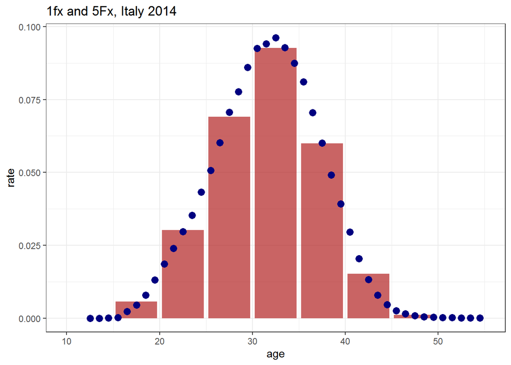

```r
age1 = 12:55

F1 =  c(0.00000, 0.00000, 0.00004, 0.00022, 0.00234, 0.00453, 0.00791,
        0.01312, 0.01864, 0.02398, 0.02969, 0.03531, 0.04324, 0.05066,
        0.06026, 0.07062, 0.07774, 0.08607, 0.09250, 0.09409, 0.09626,
        0.09286, 0.08746, 0.08107, 0.07052, 0.06013, 0.04909, 0.03918,
        0.02950, 0.02042, 0.01331, 0.00788, 0.00469, 0.00253, 0.00147,
        0.00088, 0.00042, 0.00032, 0.00022, 0.00016, 0.00009, 0.00006,
        0.00004, 0.00007)

age5 = seq(from=15, to=45, by=5)

F5 = c(0.005624, 0.030172, 0.069070, 0.092634,
       0.059998, 0.015160, 0.001124)

df1 = tibble(age=age1, rate1=F1)
df5 = tibble(age=age5, rate5=F5)

base_graph = ggplot() +
               geom_histogram(data=df5, aes(x=age+2.5,y=rate5), stat='identity', fill='firebrick', alpha=.70) +
              scale_x_continuous(limits=c(10,55)) +
              geom_point(data=df1, aes(x=age+0.5,y=rate1), size=3, color='navy') +
              theme_bw() +
              labs(x='age',y='rate',
                   title='1fx and 5Fx, Italy 2014',
                   source='Human Fertility Database')
print(base_graph)
```

Now get the constants and calculate graduated rates for 86 half-year age groups, based on the 7 $_{5}F_x$ values.

```r
url = 'http://schmert.net/calibrated-spline/REBEP/K7-10000.csv'

A = read.csv(url, header=TRUE) %>%
     select(-1) %>%   # drop row names
     as.matrix()

dim(A)
```

```
## [1] 86  7
```

The graduated rates are simply $\mathbf{A}$ times the vector of age-group rates, as in the matrix equation.

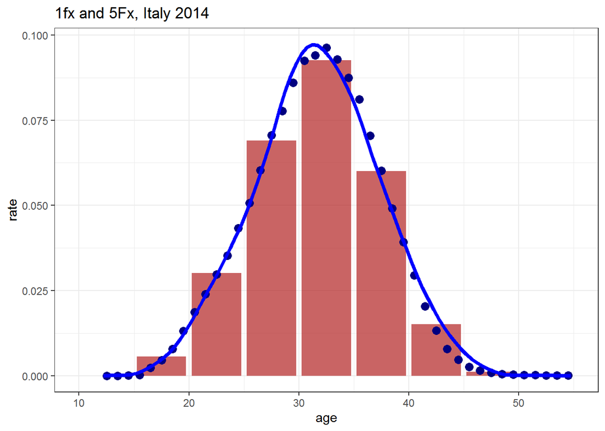

```r
f_graduated = A %*% F5

df_graduated = tibble(
          age = seq(from=12.25, to=54.75, by=.50),
          rate = f_graduated
          )

base_graph +
  geom_line(data=df_graduated, aes(x=age,y=rate), color='blue',
            size=1.5)
```

We can also check how well the graduated rates match the five-year averages. By design, this is not perfect. The graduated rates represent a compromise between *fitting the input data* and *looking like other known fertility curves*.

```r
comparison = df_graduated %>%
              group_by(age_group = 5*floor(age/5)) %>%
              summarize(F5_graduated = mean(rate)) %>%
              full_join(df5, by=c('age_group'='age'))

comparison
```

```
## # A tibble: 9 x 3
##   age_group F5_graduated    rate5
##       <dbl>        <dbl>    <dbl>
## 1        10    0.000102  NA
## 2        15    0.00570    0.00562
## 3        20    0.0298     0.0302
## 4        25    0.0701     0.0691
## 5        30    0.0922     0.0926
## 6        35    0.0574     0.0600
## 7        40    0.0190     0.0152
## 8        45    0.00221    0.00112
## 9        50    0.0000246 NA
```

## Example 2: Cameroon 2015-2020

WPP 2019 data has the following $_{5}F_x$ values for $x=15,20,\ldots,45$.

```r
F5= c(0.1058, 0.2112, 0.21, 0.1878, 0.1386, 0.0505, 0.0166)

df5 = tibble(age  = seq(15,45,5),
             rate5= F5)
```

Graduating and plotting, we get

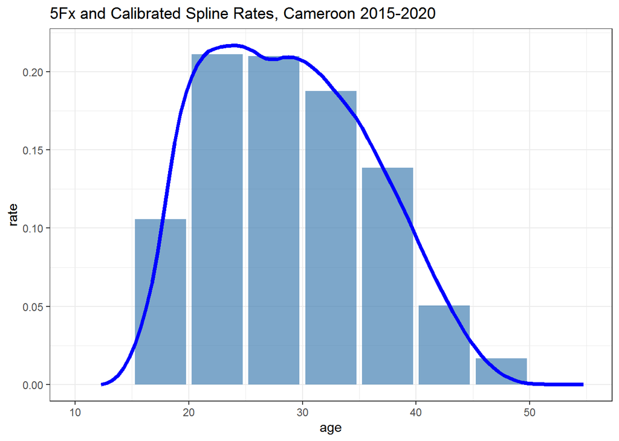

```r
f_graduated = A %*% F5

df_graduated = tibble(
          age = seq(from=12.25, to=54.75, by=.50),
          rate = f_graduated
          )

ggplot() +
     geom_histogram(data=df5, aes(x=age+2.5,y=rate5), stat='identity', fill='steelblue', alpha=.70) +
              scale_x_continuous(limits=c(10,55)) +
              theme_bw() +
              labs(x='age',y='rate',
                   title='5Fx and Calibrated Spline Rates, Cameroon 2015-2020',
                   source='UN World Population Prospects 2019') +
geom_line(data=df_graduated, aes(x=age,y=rate), color='blue',
          size=1.5)
```

## Example 3: Romania 2015-2020

WPP 2019 data has the following $_{5}F_x$ values for $x=15,20,\ldots,45$.

```r
F5= c(0.0362, 0.0715, 0.0989, 0.0776, 0.0327, 0.0068, 0.0003)

df5 = tibble(age  = seq(15,45,5),
             rate5= F5)
```

Graduating and plotting, we get

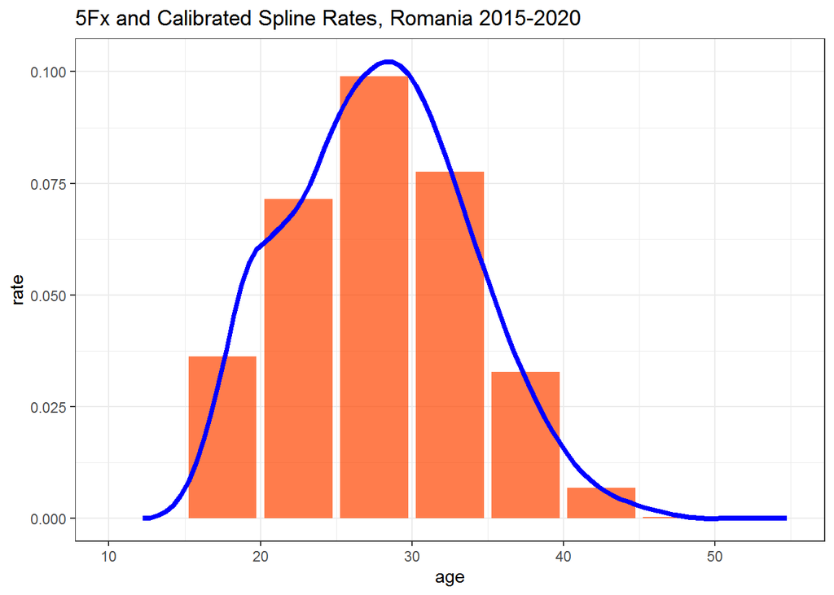

```r
f_graduated = A %*% F5

df_graduated = tibble(
          age = seq(from=12.25, to=54.75, by=.50),
          rate = f_graduated
          )

ggplot() +
     geom_histogram(data=df5, aes(x=age+2.5,y=rate5), stat='identity', fill='orangered', alpha=.70) +
              scale_x_continuous(limits=c(10,55)) +
              theme_bw() +
              labs(x='age',y='rate',
                   title='5Fx and Calibrated Spline Rates, Romania 2015-2020',
                   source='UN World Population Prospects 2019') +
geom_line(data=df_graduated, aes(x=age,y=rate), color='blue',
          size=1.5)
```